# DSE1002_Project1

Aidan Campbell

2026-10-06

```r
library(readxl) #load libraries
library(dplyr)
```

```r
library(tidyr)
library(ggplot2)
```

```r
hitting <- read.csv("C:/Users/aidan/OneDrive/Desktop/DSE1002/2016-2026_Hitting.csv")%>% #read in csv file containing the data set and rename it
  mutate(difference = batting_avg - xba) #creates new column 'difference' that shows the difference between real results and expected results

head(hitting) #displays first 6 rows of data set
```

```
##             name player_id year age  ab  pa hit single double triple home_run
## 1    Abreu, José    547989 2016  29 624 695 183    125     32      1       25
## 2 Alonso, Yonder    475174 2016  29 482 532 122     81     34      0        7
## 3   Altuve, Jose    514888 2016  26 640 717 216    145     42      5       24
## 4  Andrus, Elvis    462101 2016  27 506 568 153    107     31      7        8
## 5 Arenado, Nolan    571448 2016  25 618 696 182    100     35      6       41
## 6 Bautista, José    430832 2016  35 423 517  99     52     24      1       22
##   strikeout walk k_percent bb_percent batting_avg slg_percent on_base_percent
## 1       125   47      18.0        6.8       0.293       0.468           0.353
## 2        74   45      13.9        8.5       0.253       0.367           0.316
## 3        70   60       9.8        8.4       0.338       0.531           0.396
## 4        70   47      12.3        8.3       0.302       0.439           0.362
## 5       103   68      14.8        9.8       0.294       0.570           0.362
## 6       103   87      19.9       16.8       0.234       0.452           0.366
##   on_base_plus_slg isolated_power babip b_rbi b_total_bases
```

[output cut: 41 more lines]

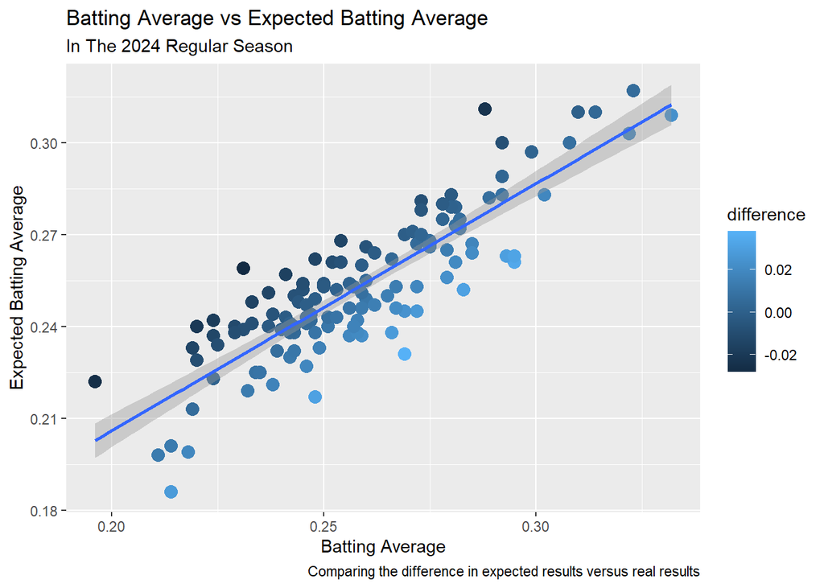

```r
ggplot(data = filter(hitting, year == "2024"), aes(x = batting_avg, y = xba)) + #creates a graph using the hitting dataset in the year 2024 with batting average and expected batting average
  geom_point(aes(color = difference), size = 3.5)+ #makes graph a scatter plot, colors scatter plot by difference, increases size of points
  geom_smooth(method=lm)+ #Creates a line best fit to the data
  labs(title = "Batting Average vs Expected Batting Average",#Adds title
    subtitle = "In The 2024 Regular Season",   #Adds subtitle
    x = "Batting Average",          #Adds label on X axis
    y = "Expected Batting Average",  #Adds label on Y-Axis
    # color = "Difference", #Adds a legend key for the color
    caption = "Comparing the difference in expected results versus real results")
```

##After observing this graph there is a weird trend where points above the line have negative differences (performed below expected) and points below the line performed above expectations can we dive into the unluckiest people on here (the ones above the line with high expected results but low real results) and see if they had better results in the following year.

##Research Question 1: Did the unluckiest hitters (in terms of batting average compared to expected batting average) in 2024 have “luckier” seasons in 2025?

```r
Unlucky2024 <- hitting %>% #Create new dataset
  filter(year == 2024)%>% #filter to use only data from 2024
  filter(player_id != 666624)%>% #Removes Christopher Morel who does not appear in 2025
  select(name, year,player_id, xba, batting_avg, difference, on_base_plus_slg)%>% #selects relevant columns for the research questions
  arrange(difference) #arranges the data set to be in order of difference (unluckiest to luckiest)

head(Unlucky2024, 5) #displays the top 5 unluckiest hitters
```

```
##                name year player_id   xba batting_avg difference
## 1    Garcia, Maikel 2024    672580 0.259       0.231     -0.028
## 2        Soto, Juan 2024    665742 0.311       0.288     -0.023
## 3  Springer, George 2024    543807 0.240       0.220     -0.020
## 4    Nimmo, Brandon 2024    607043 0.242       0.224     -0.018
## 5 Cronenworth, Jake 2024    630105 0.257       0.241     -0.016
##   on_base_plus_slg
## 1            0.613
## 2            0.988
## 3            0.674
## 4            0.726
## 5            0.714
```

```r
results2025 <- hitting%>% #creates data frame for 2025
  filter(year == 2025)%>% #filters to 2025
  filter(player_id %in% c(672580, 630105, 665742, 543807, 607043))%>% #filters out every player except the top 5 unluckiest players in 2024
  select(name,year, player_id, xba, batting_avg, difference, on_base_plus_slg)%>% #selects relevant columns
  arrange(difference) #sorts in order of unluckiest players

print(results2025) #displays the data set
```

```
##                name year player_id   xba batting_avg difference
## 1        Soto, Juan 2025    665742 0.288       0.263     -0.025
## 2    Garcia, Maikel 2025    672580 0.276       0.286      0.010
## 3    Nimmo, Brandon 2025    607043 0.252       0.262      0.010
## 4  Springer, George 2025    543807 0.291       0.309      0.018
## 5 Cronenworth, Jake 2025    630105 0.225       0.246      0.021
##   on_base_plus_slg
## 1            0.921
## 2            0.800
## 3            0.760
## 4            0.959
## 5            0.744
```

```r
UnluckyHitting <- full_join(head(Unlucky2024,5), results2025) #merges the two data sets together
```

[output not shown]

```r
print(UnluckyHitting) #displays the conjoined data sets
```

```
##                 name year player_id   xba batting_avg difference
## 1     Garcia, Maikel 2024    672580 0.259       0.231     -0.028
## 2         Soto, Juan 2024    665742 0.311       0.288     -0.023
## 3   Springer, George 2024    543807 0.240       0.220     -0.020
## 4     Nimmo, Brandon 2024    607043 0.242       0.224     -0.018
## 5  Cronenworth, Jake 2024    630105 0.257       0.241     -0.016
## 6         Soto, Juan 2025    665742 0.288       0.263     -0.025
## 7     Garcia, Maikel 2025    672580 0.276       0.286      0.010
## 8     Nimmo, Brandon 2025    607043 0.252       0.262      0.010
## 9   Springer, George 2025    543807 0.291       0.309      0.018
## 10 Cronenworth, Jake 2025    630105 0.225       0.246      0.021
##    on_base_plus_slg
## 1             0.613
## 2             0.988
## 3             0.674
## 4             0.726
## 5             0.714
## 6             0.921
## 7             0.800
## 8             0.760
## 9             0.959
## 10            0.744
```

```r
UnluckyHitting2 <- UnluckyHitting%>% #recreates the unlucky hitting data set
  pivot_wider(id_cols = c(name, player_id),
    names_from = year,
    values_from = c(xba, batting_avg)) %>% #reforms the data to be easier to read and pull from (AI/Google was used to find this function and understand it)
  mutate(difference_2024 = batting_avg_2024 - xba_2024, #recreates the difference column to be specific to 2024
    difference_2025 = batting_avg_2025 - xba_2025) %>% #recreates the difference column to be specific to 2025
  select(name, player_id,xba_2025, batting_avg_2025, difference_2025, xba_2024, batting_avg_2024, difference_2024) #selects relevant columns

print(UnluckyHitting2) #prints new data set
```

```
## # A tibble: 5 × 8
##   name              player_id xba_2025 batting_avg_2025 difference_2025 xba_2024
##   <chr>                 <int>    <dbl>            <dbl>           <dbl>    <dbl>
## 1 Garcia, Maikel       672580    0.276            0.286          0.0100    0.259
## 2 Soto, Juan           665742    0.288            0.263         -0.0250    0.311
## 3 Springer, George     543807    0.291            0.309          0.0180    0.24
## 4 Nimmo, Brandon       607043    0.252            0.262          0.0100    0.242
## 5 Cronenworth, Jake    630105    0.225            0.246          0.0210    0.257
## # ℹ 2 more variables: batting_avg_2024 <dbl>, difference_2024 <dbl>
```

##The Null hypothesis is that there is no difference in luck between years meaning that this is just who these players are. The alternative hypothesis is that the players had luckier results in 2025 meaning that 2024 was more of a fluke and less of a certainty of who this player is.

#The statistical test I am running is a paired t-test because we are comparing the means of the same set of players in one specific statistic between 2 years.

#We are running this test at a 0.05 significance level

```r
t.test(UnluckyHitting2$difference_2025, UnluckyHitting2$difference_2024, paired = TRUE, alternative = "greater", conf.level = 0.95) #run a paired t-test comparing the 2025 difference and 2024 difference to see if the mean if the 5 unluckiest hitters in 2024 were as unluckier, unluckier, or luckier (alternative hypothesis) in 2025
```

```
##
##  Paired t-test
##
## data:  UnluckyHitting2$difference_2025 and UnluckyHitting2$difference_2024
## t = 3.618, df = 4, p-value = 0.0112
## alternative hypothesis: true mean difference is greater than 0
## 95 percent confidence interval:
##  0.01141942        Inf
## sample estimates:
## mean difference
##          0.0278
```

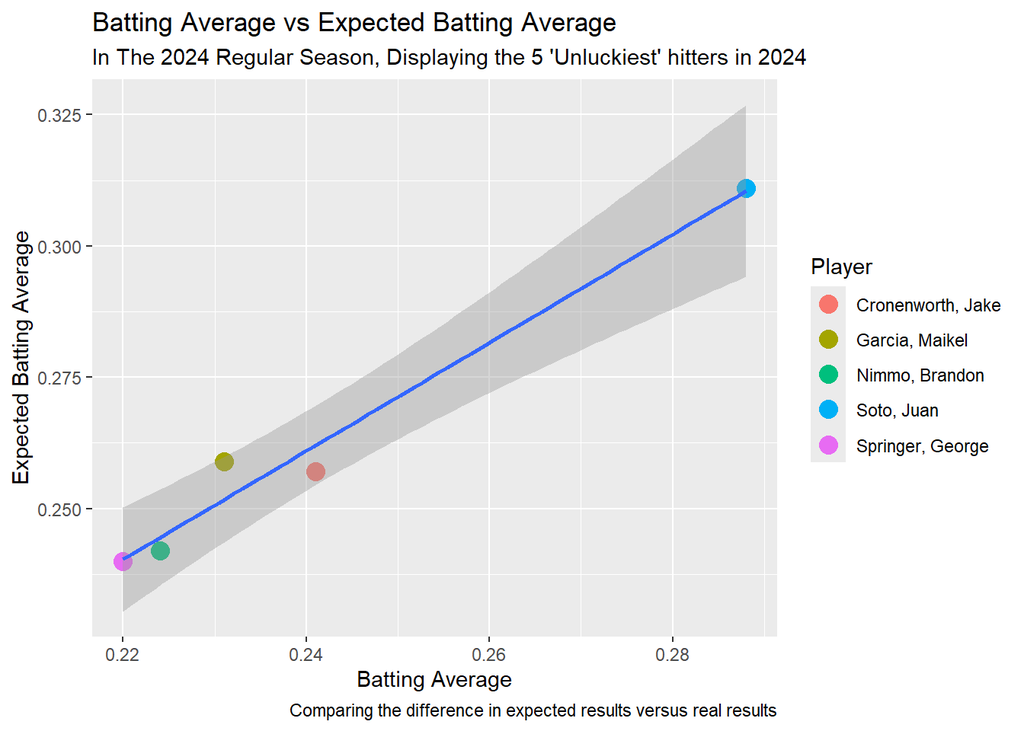

```r
ggplot(data = UnluckyHitting2, aes(x = batting_avg_2024, y = xba_2024))+ #create graph for 2024 data
  geom_point(aes(color = name), size = 4)+ #create scatterplot colored by name
  geom_smooth(method=lm)+ #Creates a line best fit to the data
  labs(title    = "Batting Average vs Expected Batting Average",#Adds title
    subtitle = "In The 2024 Regular Season, Displaying the 5 'Unluckiest' hitters in 2024",   #Adds subtitle
    x = "Batting Average",          #Adds label on X axis
    y = "Expected Batting Average",  #Adds label on Y-Axis
    color = "Player", #Adds a legend key for the color
    caption = "Comparing the difference in expected results versus real results")
```

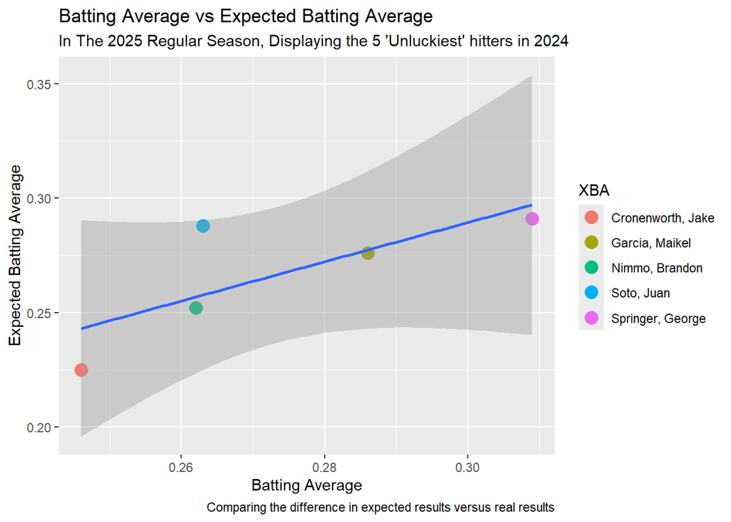

```r
ggplot(data = UnluckyHitting2, aes(x = batting_avg_2025, y = xba_2025))+ #create graph for 2025 data
  geom_point(aes(color = name), size = 4)+ #create scatter plot colored by name
  geom_smooth(method=lm)+ #Creates a line best fit to the data
  labs(title    = "Batting Average vs Expected Batting Average",#Adds title
    subtitle = "In The 2025 Regular Season, Displaying the 5 'Unluckiest' hitters in 2024",   #Adds subtitle
    x = "Batting Average",          #Adds label on X axis
    y = "Expected Batting Average",  #Adds label on Y-Axis
    color = "XBA", #Adds a legend key for the color
    caption = "Comparing the difference in expected results versus real results")
```

##Because the p value in our hypothesis test is less than 0.05 (0.01) we reject the null hypothesis and accept the alternative hypothesis that the unluckiest players in 2024 collectively had luckier seasons in 2025 and therefore progressed back towards their expected results